# Diabetes Risk Indicators

Statistical Analysis of the 2015 BRFSS Dataset

Authors

Fabrizio Eguez

Tayler Menke

James Chen

## Overview

This report investigates associations among body mass index (BMI), self-reported high blood pressure, age, income, and diabetes status using the 2015 BRFSS Diabetes Health Indicators dataset.

The analysis combines descriptive statistics, confidence intervals, hypothesis testing, analysis of variance (ANOVA), and multiple linear regression.

The findings are observational and should not be interpreted as evidence of causation or as clinically validated risk estimates.

## Dataset

The analysis uses 253,680 survey records with 21 health and demographic indicators and one diabetes-status outcome.

The statistical results use conventional unweighted methods and do not account for the complex BRFSS survey design.

## High Blood Pressure Distribution

We first examine the prevalence of self-reported high blood pressure among the 253,680 survey respondents.

Table 1: Distribution of Self-Reported High Blood Pressure

| Blood Pressure Status | Respondents | Share (%) |
| --- | --- | --- |
| No high BP | 144851 | 57.1 |
| High BP | 108829 | 42.9 |

Approximately 42.9% of respondents reported having high blood pressure, compared with 57.1% who did not.

### High Blood Pressure Visualization

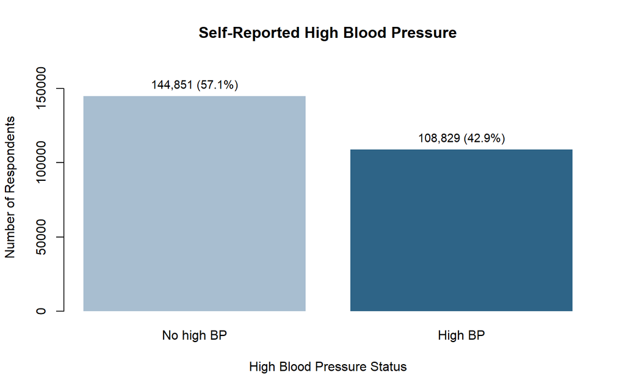

Figure 1: Distribution of self-reported high blood pressure among BRFSS respondents.

## Body Mass Index (BMI) Analysis

Body Mass Index (BMI) is a quantitative health indicator included in the BRFSS dataset. We examine its distribution and descriptive statistics to understand the characteristics of the surveyed population.

### Descriptive Statistics

Table 2: Descriptive Statistics for BMI

| Statistic | Value |
| --- | --- |
| Min | 12.00 |
| Median | 27.00 |
| Max | 98.00 |
| Mean | 28.38 |
| SD | 6.61 |
| Range | 86.00 |

The average BMI among the 253,680 respondents was **28.38**, with a median of **27** and a standard deviation of **6.61**. Observed BMI values ranged from **12 to 98**.

### BMI Distribution

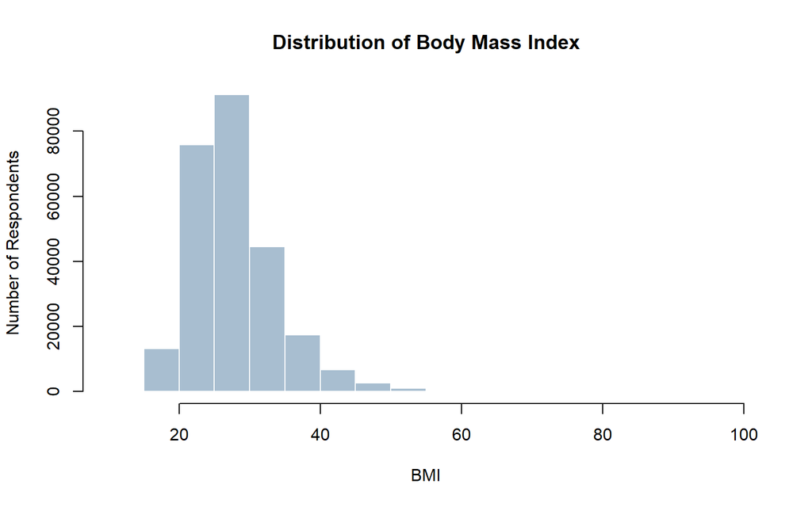

Figure 2: Distribution of BMI across BRFSS respondents.

The distribution is right-skewed, with most BMI values concentrated toward the lower end of the observed range and a smaller number of respondents reporting substantially higher BMI values.

## BMI by High Blood Pressure Status

To explore the relationship between BMI and high blood pressure, we compare BMI distributions among respondents who reported high blood pressure and those who did not.

### Group Comparison

Table 3: BMI Summary by High Blood Pressure Status

| Blood Pressure Status | Respondents | Mean BMI | Median BMI | Standard Deviation |
| --- | --- | --- | --- | --- |
| No high BP | 144851 | 27.16 | 26 | 6.11 |
| High BP | 108829 | 30.01 | 29 | 6.89 |

Respondents reporting high blood pressure had a higher average BMI (**30.01**) compared with those without high blood pressure (**27.16**).

This represents a difference of approximately **2.85 BMI points**.

### Distribution Comparison

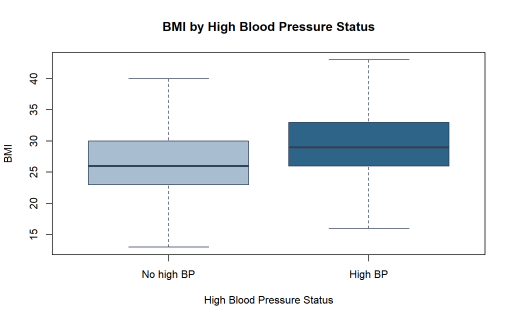

Figure 3: BMI distributions by self-reported high blood pressure status. Outlier points are hidden for readability.

### Interpretation

The boxplot illustrates differences in the central tendency and variability of BMI between the two groups.

Respondents with high blood pressure generally had higher BMI values than those without high blood pressure.

These findings establish a **descriptive association**, not a causal relationship between BMI and high blood pressure.

## Confidence Interval Analysis

Confidence intervals provide a range of plausible values for a population mean, based on sample observations and statistical assumptions.

We constructed conventional 95% confidence intervals for overall mean BMI and for two age groups: respondents aged 18–24 and respondents aged 50–54.

### Overall and Age-Group Confidence Intervals

Table 4: 95% Confidence Intervals for Mean BMI

| Population Group | Respondents | Mean BMI | 95% Confidence Interval |
| --- | --- | --- | --- |
| All respondents | 253,680 | 28.38 | [28.36, 28.41] |
| Ages 18–24 | 5,700 | 26.09 | [25.92, 26.26] |
| Ages 50–54 | 26,314 | 28.94 | [28.86, 29.03] |

### Interpretation

**Overall BMI.** The sample mean BMI was 28.38, with a conventional 95% confidence interval of [28.36, 28.41]. The narrow interval reflects the large sample size.

**Age-group comparison.** Respondents aged 18–24 had a mean BMI of 26.09, compared with 28.94 among respondents aged 50–54.

The corresponding confidence intervals do not overlap, and the observed difference in mean BMI is approximately 2.85 points.

The younger age group has a wider confidence interval, consistent with its smaller sample size.

### Statistical Considerations

These intervals use standard unweighted methods that assume independent observations. They do not account for the BRFSS complex survey sampling design.

Consequently, they should not be interpreted as survey-design-adjusted estimates for the U.S. population.

## Hypothesis Testing

We conducted two hypothesis tests to investigate BMI in the surveyed population and its association with reported diabetes status.

### Statistical Test Results

Table 5: Summary of BMI Hypothesis Tests

| Test | Comparison | t-statistic | Degrees of Freedom | p-value |
| --- | --- | --- | --- | --- |
| One-sample t-test | Mean BMI > 25 | 257.78 | 253679 | < 0.001 |
| Welch two-sample t-test | No diabetes vs. diabetes | -101.38 | 44199 | < 0.001 |

### One-Sample t-Test: Mean BMI Greater Than 25

**Research question:** Is the average BMI greater than 25?

- **Null hypothesis:** Population mean BMI is at most 25.
- **Alternative hypothesis:** Population mean BMI exceeds 25.
- **Sample mean BMI:** 28.38

The one-sample t-test produced a t-statistic of approximately 257.78 (p < 0.001).

We reject the null hypothesis under the conventional test assumptions. The observed mean BMI exceeds the benchmark by approximately **3.38 BMI points**.

The large sample size contributes to the very high test statistic and small p-value.

### Welch Two-Sample t-Test: Diabetes Status

**Research question:** Does mean BMI differ between respondents reporting diabetes and those reporting no diabetes?

- **Null hypothesis:** The two groups have equal population mean BMI.
- **Alternative hypothesis:** Their population mean BMIs differ.

| Reported diabetes status | Mean BMI |
| --- | --- |
| No diabetes | 27.74 |
| Diabetes | 31.94 |

The Welch two-sample t-test produced a t-statistic of approximately -101.38 (p < 0.001).

Respondents reporting diabetes had a mean BMI approximately **4.20 points higher** than respondents reporting no diabetes.

Respondents reporting prediabetes were excluded from this two-group comparison.

### Interpretation

Both tests show statistically significant results under conventional unweighted assumptions. However, these tests do not account for the BRFSS complex survey sampling design.

The findings describe differences and associations in reported health indicators; they do not establish causation.

## BMI Differences Across Age Groups

To investigate how BMI varies across age categories, we compared mean BMI across the 13 age groups represented in the BRFSS dataset.

The original age categories were preserved rather than replacing them with artificially generated exact ages.

### Mean BMI by Age Group

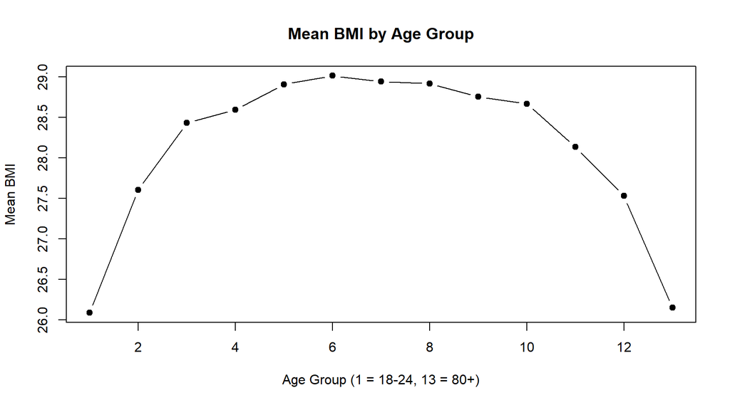

Figure 4: Mean BMI across the 13 BRFSS age categories.

Mean BMI generally increases from early adulthood through middle age, peaking around ages 45–49, before declining among older age groups.

This is a cross-sectional comparison of respondents, not evidence of how an individual’s BMI changes over time.

### One-Way ANOVA

We conducted a one-way analysis of variance to determine whether mean BMI differs across age groups.

**Null hypothesis:** All 13 age groups have equal population mean BMI.

**Alternative hypothesis:** At least one age group has a different population mean BMI.

Table 6: One-Way ANOVA: BMI by Age Group

|  | Degrees of Freedom | Sum of Squares | Mean Square | F-statistic | p-value |
| --- | --- | --- | --- | --- | --- |
| factor(Age) | 12 | 171347 | 14278.918 | 332.057 | 0 |
| Residuals | 253667 | 10908042 | 43.001 | NA | NA |

### Effect Size and Interpretation

Table 7: ANOVA Results and Effect Size

| Metric | Value |
| --- | --- |
| F-statistic | 332.1 |
| Between-group degrees of freedom | 12 |
| Residual degrees of freedom | 253667 |
| p-value | < 0.001 |
| Eta-squared | 0.0155 |
| Variance explained | 1.55% |

The ANOVA identified statistically significant differences in mean BMI across age groups:

**F(12, 253667) = 332.1, p < 0.001.**

However, statistical significance does not necessarily indicate a large association.

The eta-squared effect size was approximately **0.0155**, meaning age-group membership explained only **1.55% of the observed variation in BMI**.

These findings indicate meaningful descriptive differences across age categories, but substantial BMI variation remains unexplained by age group alone.

As with the other analyses, the conventional ANOVA does not account for the complex BRFSS survey sampling design.

## Multiple Linear Regression

We fitted a multiple linear regression model to examine how BMI varies across age and income categories.

Both predictors use their original BRFSS categorical values rather than artificially generated exact ages or income amounts.

### Model Performance

Table 8: Multiple Linear Regression Model Summary

| Metric | Value |
| --- | --- |
| Observations | 253,680 |
| R-squared | 0.0331 |
| Adjusted R-squared | 0.0330 |
| Residual standard error | 6.499 |
| F-statistic | F(19, 253660) = 456.6 |
| Model p-value | < 0.001 |

The model is statistically significant overall (F(19, 253660) = 456.6, p < 0.001).

However, its **R-squared of 0.0331** indicates that age and income categories collectively explain only approximately **3.31% of the observed variation in BMI**.

This is relatively low explanatory power, suggesting that most BMI variation is associated with factors outside this model.

### Regression Coefficients

The reference categories are:

- **Age Group 1:** 18–24 years
- **Income Group 1:** Less than $10,000

Each age-group coefficient represents the estimated difference in BMI relative to ages 18–24, holding income category constant.

Each income-group coefficient represents the estimated difference relative to the lowest income category, holding age group constant.

Table 9: Regression Coefficients and 95% Confidence Intervals

| Predictor | Estimate | 95% CI Lower | 95% CI Upper | p-value |
| --- | --- | --- | --- | --- |
| (Intercept) | 27.140 | 26.932 | 27.347 | < 0.001 |
| Age_group2 | 1.685 | 1.462 | 1.908 | < 0.001 |
| Age_group3 | 2.709 | 2.501 | 2.917 | < 0.001 |
| Age_group4 | 2.993 | 2.791 | 3.194 | < 0.001 |
| Age_group5 | 3.369 | 3.172 | 3.566 | < 0.001 |
| Age_group6 | 3.444 | 3.252 | 3.636 | < 0.001 |
| Age_group7 | 3.288 | 3.102 | 3.475 | < 0.001 |
| Age_group8 | 3.213 | 3.029 | 3.397 | < 0.001 |
| Age_group9 | 2.957 | 2.775 | 3.140 | < 0.001 |
| Age_group10 | 2.769 | 2.586 | 2.952 | < 0.001 |
| Age_group11 | 2.116 | 1.928 | 2.304 | < 0.001 |
| Age_group12 | 1.378 | 1.181 | 1.574 | < 0.001 |
| Age_group13 | -0.130 | -0.325 | 0.065 | 0.191 |
| Income_group2 | 0.275 | 0.101 | 0.449 | 0.002 |
| Income_group3 | -0.175 | -0.339 | -0.012 | 0.036 |
| Income_group4 | -0.414 | -0.571 | -0.257 | < 0.001 |
| Income_group5 | -0.651 | -0.803 | -0.500 | < 0.001 |
| Income_group6 | -0.936 | -1.082 | -0.791 | < 0.001 |
| Income_group7 | -1.358 | -1.501 | -1.216 | < 0.001 |
| Income_group8 | -2.398 | -2.534 | -2.262 | < 0.001 |

### Key Findings

**Age differences.** Respondents aged 45–49 (Age Group 6) had an estimated BMI approximately **3.44 points higher** than respondents aged 18–24, holding income category constant.

**Income differences.** Respondents in the highest income category ($75,000 or more) had an estimated BMI approximately **2.40 points lower** than those in the lowest income category, holding age group constant.

**Older age groups.** Age Group 13 (80+) was not statistically significantly different from Age Group 1 after adjusting for income (p = 0.191).

### Interpretation and Limitations

Although the regression is statistically significant, its explanatory power is limited.

Age and income categories capture only a small portion of BMI variation in this dataset.

The results describe statistical associations, not causal effects. —